# PML Project

krrish16

15 December 2018

# Introduction

Using devices such as Jawbone Up, Nike FuelBand, and Fitbit it is now possible to collect a large amount of data about personal activity relatively inexpensively.One thing that people regularly do is quantify how much of a particular activity they do, but they rarely quantify how well they do it. They were asked to perform barbell lifts correctly and incorrectly in 5 different ways. In this project we will use data from accelerometers on the belt, forearm, arm, and dumbell of 6 participants and predict the manner in which they did the exercise.

# Loading data and required packages

```r
library(caret)
library(rpart)
library(rattle)
```

```r
library(rpart.plot)
library(gbm)
library(parallel)
library(doParallel)
cluster <- makeCluster(detectCores() - 1) # convention to leave 1 core for OS
registerDoParallel(cluster)

traindata <- read.csv(url("https://d396qusza40orc.cloudfront.net/predmachlearn/pml-training.csv"),header=TRUE)
dim(traindata)
```

```
## [1] 19622   160
```

```r
testdata <- read.csv(url("https://d396qusza40orc.cloudfront.net/predmachlearn/pml-testing.csv"),header=TRUE)
dim(testdata)
```

```
## [1]  20 160
```

```r
str(traindata)
```

[output not shown]

[output cut: 86 more lines]

The training data set consists of 19622 observations and 160 columns aslo many columns have NA values or blank value. So we will remove them, because they will not produce any information.Here we remove columns having at least 90% of NA or blank values on the training dataset

# Cleaning Data

```r
remove <- which(colSums(is.na(traindata) |traindata=="") > 0.9*nrow(traindata))
traindata_cleaned <- traindata[,-remove]

# Also first 7 columns of training data set contain data which is not necessary for prediction
traindata_cleaned <- traindata_cleaned[,-c(1:7)]
dim(traindata_cleaned)
```

```
## [1] 19622    53
```

```r
# Similarly cleaning Test Data Set
remove <- which(colSums(is.na(testdata) |testdata=="")>0.9*nrow(testdata))
testdata_cleaned <- testdata[,-remove]
testdata_cleaned <- testdata_cleaned[,-1]
dim(testdata_cleaned)
```

```
## [1] 20 59
```

# Partitioning the data

```r
set.seed(1234)
inTrain <- createDataPartition(traindata_cleaned$classe, p=0.75, list=FALSE)
Train <- traindata_cleaned[inTrain,]
Test <- traindata_cleaned[-inTrain,]
dim(Train);dim(Test)
```

```
## [1] 14718    53
```

```
## [1] 4904   53
```

# Using Classificaion Tree

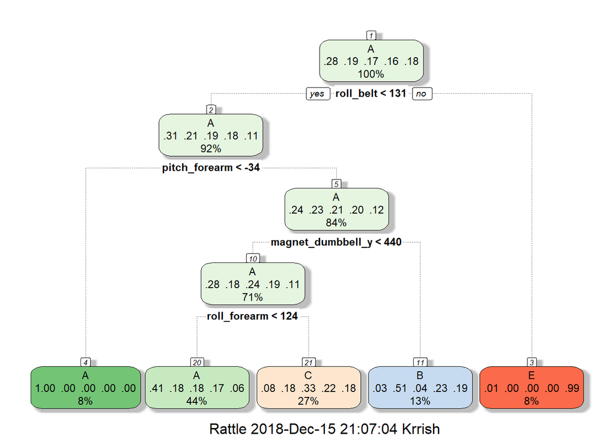

```r
trControl <- trainControl(method="cv", number=5 , allowParallel = TRUE)
Class_tree_model <- train(classe~., data=Train, method="rpart", trControl=trControl)
fancyRpartPlot(Class_tree_model$finalModel)
```

```r
class_tree_pred <- predict(Class_tree_model,newdata=Test)
class_tree_confmat <- confusionMatrix(Test$classe,class_tree_pred)
print(class_tree_confmat)
```

```
## Confusion Matrix and Statistics
##
##           Reference
## Prediction    A    B    C    D    E
##          A 1275   28   88    0    4
##          B  390  340  219    0    0
##          C  416   31  408    0    0
##          D  356  141  307    0    0
##          E  134  131  230    0  406
##
## Overall Statistics
##
##                Accuracy : 0.4953
##                  95% CI : (0.4812, 0.5094)
##     No Information Rate : 0.5243
##     P-Value [Acc > NIR] : 1
##
##                   Kappa : 0.3399
##  Mcnemar's Test P-Value : NA
##
## Statistics by Class:
##
##                      Class: A Class: B Class: C Class: D Class: E
## Sensitivity            0.4959  0.50671   0.3259       NA  0.99024
## Specificity            0.9486  0.85613   0.8776   0.8361  0.88985
## Pos Pred Value         0.9140  0.35827   0.4772       NA  0.45061
## Neg Pred Value         0.6307  0.91631   0.7916       NA  0.99900
## Prevalence             0.5243  0.13683   0.2553   0.0000  0.08361
## Detection Rate         0.2600  0.06933   0.0832   0.0000  0.08279
## Detection Prevalence   0.2845  0.19352   0.1743   0.1639  0.18373
## Balanced Accuracy      0.7222  0.68142   0.6017       NA  0.94005
```

We see that the accuracy of Classification tree model is very low, about 50%.Lets try using Random Forests

# Using Random Forests

```r
rf_model <- train(classe~., data=Train, method="rf", trControl=trControl,verbose = FALSE)
print(rf_model)
```

```
## Random Forest
##
## 14718 samples
##    52 predictor
##     5 classes: 'A', 'B', 'C', 'D', 'E'
##
## No pre-processing
## Resampling: Cross-Validated (5 fold)
## Summary of sample sizes: 11776, 11773, 11775, 11773, 11775
## Resampling results across tuning parameters:
##
##   mtry  Accuracy   Kappa
##    2    0.9913027  0.9889975
##   27    0.9923898  0.9903731
##   52    0.9874976  0.9841854
##
## Accuracy was used to select the optimal model using the largest value.
## The final value used for the model was mtry = 27.
```

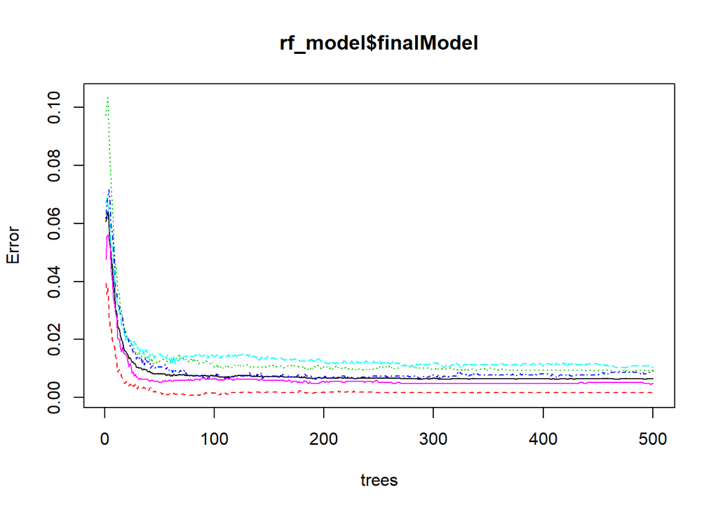

```r
plot(rf_model$finalModel)
```

```r
rf_pred <- predict(rf_model,newdata=Test)
rf_confmat <- confusionMatrix(Test$classe,rf_pred)
print(rf_confmat)
```

```
## Confusion Matrix and Statistics
##
##           Reference
## Prediction    A    B    C    D    E
##          A 1395    0    0    0    0
##          B    7  939    3    0    0
##          C    0    8  844    3    0
##          D    0    1    9  793    1
##          E    0    0    1    0  900
##
## Overall Statistics
##
##                Accuracy : 0.9933
##                  95% CI : (0.9906, 0.9954)
##     No Information Rate : 0.2859
##     P-Value [Acc > NIR] : < 2.2e-16
##
##                   Kappa : 0.9915
##  Mcnemar's Test P-Value : NA
##
## Statistics by Class:
##
##                      Class: A Class: B Class: C Class: D Class: E
## Sensitivity            0.9950   0.9905   0.9848   0.9962   0.9989
## Specificity            1.0000   0.9975   0.9973   0.9973   0.9998
## Pos Pred Value         1.0000   0.9895   0.9871   0.9863   0.9989
## Neg Pred Value         0.9980   0.9977   0.9968   0.9993   0.9998
## Prevalence             0.2859   0.1933   0.1748   0.1623   0.1837
## Detection Rate         0.2845   0.1915   0.1721   0.1617   0.1835
## Detection Prevalence   0.2845   0.1935   0.1743   0.1639   0.1837
## Balanced Accuracy      0.9975   0.9940   0.9911   0.9968   0.9993
```

```r
print(rf_confmat$overall[1])
```

```
##  Accuracy
## 0.9932708
```

With Random forest, the accuracy is 99.4% with cross-validation with 5 folds which is a good accuracy score.Now we use Gradient boosting.